# FastRTutorial

2023-04-06

# Lesson 1: Getting Started

- Install R
- Start up R (or RStudio terminal)

# Lesson 2: First R Steps

```r
1+1
```

```
## [1] 2
```

### Example: Nile River Data

```r
mean(Nile)
```

```
## [1] 919.35
```

```r
Nile
```

```
## Time Series:
## Start = 1871
## End = 1970
## Frequency = 1
##   [1] 1120 1160  963 1210 1160 1160  813 1230 1370 1140  995  935 1110  994 1020
##  [16]  960 1180  799  958 1140 1100 1210 1150 1250 1260 1220 1030 1100  774  840
##  [31]  874  694  940  833  701  916  692 1020 1050  969  831  726  456  824  702
##  [46] 1120 1100  832  764  821  768  845  864  862  698  845  744  796 1040  759
##  [61]  781  865  845  944  984  897  822 1010  771  676  649  846  812  742  801
##  [76] 1040  860  874  848  890  744  749  838 1050  918  986  797  923  975  815
##  [91] 1020  906  901 1170  912  746  919  718  714  740
```

```r
length(Nile)
```

```
## [1] 100
```

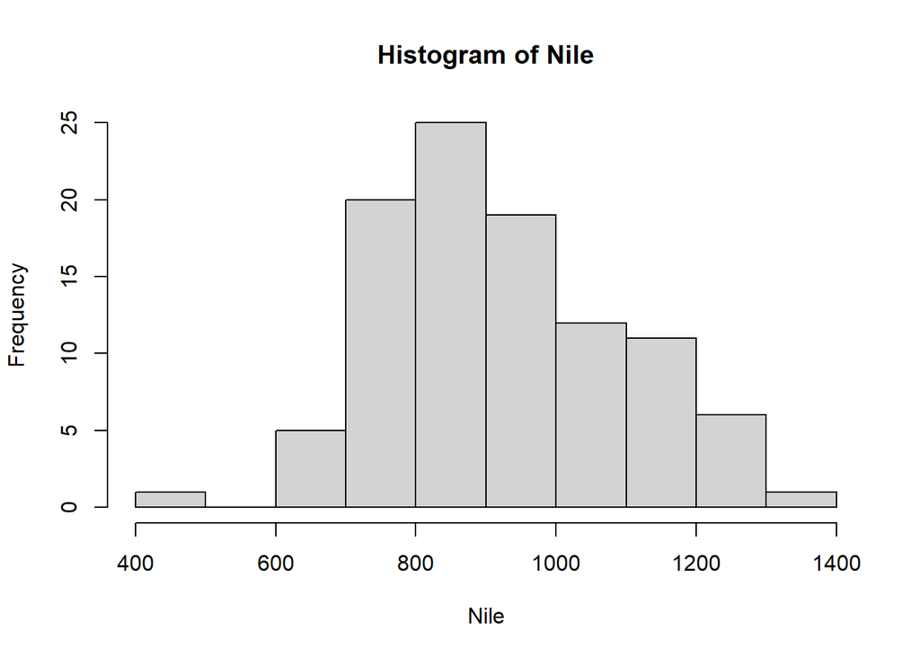

```r
hist(Nile)
```

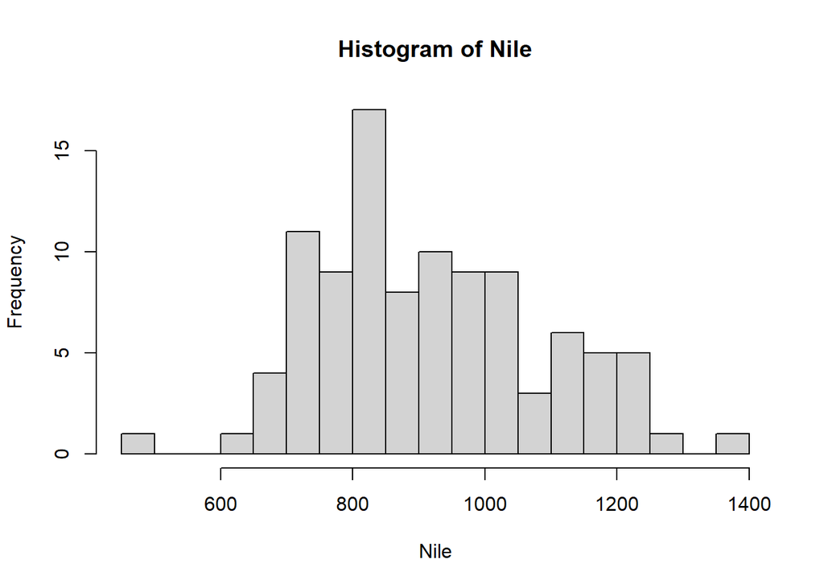

```r
hist(Nile, breaks=20)
```

Call helper to find out more about a function

```r
?hist
```

```
## starting httpd help server ... done
```

# Lesson 3: Vectors and Indices

### Accessing elements

Use subscripts or indices with brackets Example: access 2nd element of Nile vector

```r
Nile[2]
```

```
## [1] 1160
```

**Build a Vector:**

- **Concatenation:** c() builds from individual elements
- **Colon:** builds by selecting a range

Example: access 2nd, 3rd, and 4th elements of Nile vector

```r
Nile[c(2,3,4)]
```

```
## [1] 1160  963 1210
```

```r
Nile[2:5]
```

```
## [1] 1160  963 1210 1160
```

```r
mean(Nile[81:100])
```

```
## [1] 877.05
```

Make a copy of a slice of Nile data:

```r
n81100 <- Nile[81:100]
mean(n81100)
```

```
## [1] 877.05
```

```r
sd(n81100)
```

```
## [1] 125.5583
```

```r
n81100[1]
```

```
## [1] 744
```

```r
Nile[81]
```

```
## [1] 744
```

```r
length(Nile)
```

```
## [1] 100
```

```r
length(n81100)
```

```
## [1] 20
```

# Lesson 4: More on Vectors

**Sum:** sum elements of a vector

```r
sum(c(5,12,13))
```

```
## [1] 30
```

Interpretation: there are 7 years in which the Nile river level exceeded 1200

```r
sum(Nile > 1200)
```

```
## [1] 7
```

```r
x <- c(5,12,13)
x
```

```
## [1]  5 12 13
```

```r
x > 8
```

```
## [1] FALSE  TRUE  TRUE
```

```r
sum(x > 8)
```

```
## [1] 2
```

**Which:** determine which elements of vector carry a property/meet a condition

- Identify indices where Nile > 1200 is TRUE

```r
which(Nile > 1200)
```

```
## [1]  4  8  9 22 24 25 26
```

- Identify and store indices where Nile > 1200 is TRUE
- Then find length of these indices

```r
which1200 <- which(Nile > 1200)
which1200
```

```
## [1]  4  8  9 22 24 25 26
```

```r
length(which1200)
```

```
## [1] 7
```

- Identify and store indices where Nile > 1200 is TRUE
- Then find values at those indices

```r
which1200 <- which(Nile > 1200)
Nile[which1200]
```

```
## [1] 1210 1230 1370 1210 1250 1260 1220
```

- Find values of Nile which are > 1200
- Eliminates which1200 middle man

```r
Nile[Nile > 1200]
```

```
## [1] 1210 1230 1370 1210 1250 1260 1220
```

**Negative Indices**

```r
x <- c(5,12,13,8)
x
```

```
## [1]  5 12 13  8
```

```r
x[-1]
```

```
## [1] 12 13  8
```

```r
x[c(-1,-4)]
```

```
## [1] 12 13
```

# Lesson 5: On to Data Frames

### Load Data Frame

```r
head(ToothGrowth)
```

```
##    len supp dose
## 1  4.2   VC  0.5
## 2 11.5   VC  0.5
## 3  7.3   VC  0.5
## 4  5.8   VC  0.5
## 5  6.4   VC  0.5
## 6 10.0   VC  0.5
```

### **Extract from Data Frame**

df[rows we want, columns we want]

```r
tg <- ToothGrowth
mean(tg$len)
```

```
## [1] 18.81333
```

```r
tg[3,1]
```

```
## [1] 7.3
```

```r
tg$len[3]
```

```
## [1] 7.3
```

```r
mean(tg[,1])
```

```
## [1] 18.81333
```

Extract subsets:

```r
z <- tg[2:5, c(1,3)]
z
```

```
##    len dose
## 2 11.5  0.5
## 3  7.3  0.5
## 4  5.8  0.5
## 5  6.4  0.5
```

```r
y <- tg[ , c(1,3)]
head(y)
```

```
##    len dose
## 1  4.2  0.5
## 2 11.5  0.5
## 3  7.3  0.5
## 4  5.8  0.5
## 5  6.4  0.5
## 6 10.0  0.5
```

```r
nrow(ToothGrowth)
```

```
## [1] 60
```

```r
length(tg$len)
```

```
## [1] 60
```

```r
length(tg$supp)
```

```
## [1] 60
```

```r
length(tg$dose)
```

```
## [1] 60
```

Apply **head** to vector

```r
head(ToothGrowth$len)
```

```
## [1]  4.2 11.5  7.3  5.8  6.4 10.0
```

```r
head(ToothGrowth$len, 10)
```

```
##  [1]  4.2 11.5  7.3  5.8  6.4 10.0 11.2 11.2  5.2  7.0
```

### Creating Data Frames

```r
x <- c(5,12,13)
y <- c('abc','de','z')
d <- data.frame(x,y)
d
```

```
##    x   y
## 1  5 abc
## 2 12  de
## 3 13   z
```

```r
y <- c('abc','de','z')
y[2]
```

```
## [1] "de"
```

```r
z <- tg[ , -2]
head(z)
```

```
##    len dose
## 1  4.2  0.5
## 2 11.5  0.5
## 3  7.3  0.5
## 4  5.8  0.5
## 5  6.4  0.5
## 6 10.0  0.5
```

# Lesson 6: R Factor Class

```r
class(tg)
```

```
## [1] "data.frame"
```

```r
class(tg$supp)
```

```
## [1] "factor"
```

R factors are used when we have categorical variables. Find the list of categories in tg$supp as follows:

```r
levels(tg$supp)
```

```
## [1] "OJ" "VC"
```

# Lesson 7: Extracting Rows/Columns from Data Frames

Extract vector elements:

```r
which1200 <- which(Nile > 1200)
Nile[which1200]
```

```
## [1] 1210 1230 1370 1210 1250 1260 1220
```

Extract data frame rows or columns:

```r
whichOJ <- which(tg$supp == 'OJ')
whichVC <- which(tg$supp == 'VC')
mean(tg[whichOJ,1])
```

```
## [1] 20.66333
```

```r
mean(tg[whichVC,1])
```

```
## [1] 16.96333
```

```r
tgoj <- tg[tg$supp == 'OJ',]
tgvc <- tg[tg$supp == 'VC',]
mean(tgoj$len)
```

```
## [1] 20.66333
```

```r
mean(tgvc$len)
```

```
## [1] 16.96333
```

# Lesson 8: More Examples of Extracting Rows, Columns

Multiple Conditions:

```r
tg[tg$supp == 'OJ' & tg$len < 8.8, ]
```

```
##    len supp dose
## 37 8.2   OJ  0.5
```

```r
tg[tg$len > 28 | tg$dose == 1.0,]
```

```
##     len supp dose
## 11 16.5   VC    1
## 12 16.5   VC    1
## 13 15.2   VC    1
## 14 17.3   VC    1
## 15 22.5   VC    1
## 16 17.3   VC    1
## 17 13.6   VC    1
## 18 14.5   VC    1
## 19 18.8   VC    1
## 20 15.5   VC    1
## 23 33.9   VC    2
## 26 32.5   VC    2
## 30 29.5   VC    2
## 41 19.7   OJ    1
## 42 23.3   OJ    1
## 43 23.6   OJ    1
## 44 26.4   OJ    1
## 45 20.0   OJ    1
## 46 25.2   OJ    1
## 47 25.8   OJ    1
## 48 21.2   OJ    1
## 49 14.5   OJ    1
## 50 27.3   OJ    1
## 56 30.9   OJ    2
## 59 29.4   OJ    2
```

Saving Results

```r
w <- tg[tg$len > 28 | tg$dose == 1.0,]
head(w)
```

```
##     len supp dose
## 11 16.5   VC    1
## 12 16.5   VC    1
## 13 15.2   VC    1
## 14 17.3   VC    1
## 15 22.5   VC    1
## 16 17.3   VC    1
```

```r
lendose <- tg[,c(1,3)]
head(lendose)
```

```
##    len dose
## 1  4.2  0.5
## 2 11.5  0.5
## 3  7.3  0.5
## 4  5.8  0.5
## 5  6.4  0.5
## 6 10.0  0.5
```

Specify columns by name instead of number:

```r
lendose <- tg[,c('len','dose')]
head(lendose)
```

```
##    len dose
## 1  4.2  0.5
## 2 11.5  0.5
## 3  7.3  0.5
## 4  5.8  0.5
## 5  6.4  0.5
## 6 10.0  0.5
```

Logical operation on vectors:

```r
exts <- Nile[Nile < 800 | Nile > 1300]
head(exts)
```

```
## [1] 1370  799  774  694  701  692
```

```r
length(Nile[Nile < 800 | Nile > 1300])
```

```
## [1] 27
```

# Lesson 9: The tapply Function

In English: “Split the vector **tg$len** into two groups, according to the value of **tg$supp**, then apply **mean** to each group.”

```r
tapply(tg$len,tg$supp,mean)
```

```
##       OJ       VC
## 20.66333 16.96333
```

Note that the result was returned as a vector, which we could save by assigning it to, say **z**:

```r
z <- tapply(tg$len,tg$supp,mean)
z[1]
```

```
##       OJ
## 20.66333
```

```r
z[2]
```

```
##       VC
## 16.96333
```

```r
x <- c(8,5,12,13)
g <- c('M',"F",'M','M')
tapply(x,g,mean)
```

```
##  F  M
##  5 11
```

```r
tapply(PlantGrowth$weight,PlantGrowth$group,length)
```

```
## ctrl trt1 trt2
##   10   10   10
```

Mtcars Dataset:

```r
row.names(mtcars)
```

```
##  [1] "Mazda RX4"           "Mazda RX4 Wag"       "Datsun 710"
##  [4] "Hornet 4 Drive"      "Hornet Sportabout"   "Valiant"
##  [7] "Duster 360"          "Merc 240D"           "Merc 230"
## [10] "Merc 280"            "Merc 280C"           "Merc 450SE"
## [13] "Merc 450SL"          "Merc 450SLC"         "Cadillac Fleetwood"
## [16] "Lincoln Continental" "Chrysler Imperial"   "Fiat 128"
## [19] "Honda Civic"         "Toyota Corolla"      "Toyota Corona"
## [22] "Dodge Challenger"    "AMC Javelin"         "Camaro Z28"
## [25] "Pontiac Firebird"    "Fiat X1-9"           "Porsche 914-2"
## [28] "Lotus Europa"        "Ford Pantera L"      "Ferrari Dino"
## [31] "Maserati Bora"       "Volvo 142E"
```

```r
row.names(mtcars)[7]
```

```
## [1] "Duster 360"
```

```r
row.names(mtcars)[7] <- 'Dustpan'
row.names(mtcars)[7]
```

```
## [1] "Dustpan"
```

# Lesson 10: Data Cleaning

```r
pima <- read.csv('http://heather.cs.ucdavis.edu/FasteR/data/Pima.csv',header=TRUE)
head(pima)
```

```
##   pregnant glucose diastolic triceps insulin  bmi diabetes age test
## 1        6     148        72      35       0 33.6    0.627  50    1
## 2        1      85        66      29       0 26.6    0.351  31    0
## 3        8     183        64       0       0 23.3    0.672  32    1
## 4        1      89        66      23      94 28.1    0.167  21    0
## 5        0     137        40      35     168 43.1    2.288  33    1
## 6        5     116        74       0       0 25.6    0.201  30    0
```

The **dim** function tells us that there are 768 people in the study, 9 variables measured on each.

```r
dim(pima)
```

```
## [1] 768   9
```

**Table Function:**

```r
table(pima$glucose)
```

```
##
##   0  44  56  57  61  62  65  67  68  71  72  73  74  75  76  77  78  79  80  81
##   5   1   1   2   1   1   1   1   3   4   1   3   4   2   2   2   4   3   6   6
##  82  83  84  85  86  87  88  89  90  91  92  93  94  95  96  97  98  99 100 101
##   3   6  10   7   3   7   9   6  11   9   9   7   7  13   8   9   3  17  17   9
## 102 103 104 105 106 107 108 109 110 111 112 113 114 115 116 117 118 119 120 121
##  13   9   6  13  14  11  13  12   6  14  13   5  11  10   7  11   6  11  11   6
## 122 123 124 125 126 127 128 129 130 131 132 133 134 135 136 137 138 139 140 141
##  12   9  11  14   9   5  11  14   7   5   5   5   6   4   8   8   5   8   5   5
## 142 143 144 145 146 147 148 149 150 151 152 153 154 155 156 157 158 159 160 161
##   5   6   7   5   9   7   4   1   3   6   4   2   6   5   3   2   8   2   1   3
## 162 163 164 165 166 167 168 169 170 171 172 173 174 175 176 177 178 179 180 181
##   6   3   3   4   3   3   4   1   2   3   1   6   2   2   2   1   1   5   5   5
## 182 183 184 186 187 188 189 190 191 193 194 195 196 197 198 199
##   1   3   3   1   4   2   4   1   1   2   3   2   3   4   1   1
```

Remove instances where glucose level is 0

```r
pg <- pima$glucose
pg1 <- pg[pg > 0]
length(pg1)
```

```
## [1] 763
```

```r
mean(pg)
```

```
## [1] 120.8945
```

```r
mean(pg1)
```

```
## [1] 121.6868
```

Encode 0 values as NA instead

```r
pima$glucose[pima$glucose == 0] <- NA
sum(is.na(pima$glucose))
```

```
## [1] 5
```

Mean function does not skip over NA values by default

```r
mean(pima$glucose)
```

```
## [1] NA
```

```r
mean(pima$glucose, na.rm=TRUE)
```

```
## [1] 121.6868
```

# Lesson 11: The R List Class

```r
mtmpg <- mtcars$mpg
```

Split the vector into three vectors, one for 4-cylinder cars, one for 6-cylinder cars, and one for 8-cylinder cars

Option A:

```r
mt4 <- mtmpg[mtcars$cyl == 4]
mt6 <- mtmpg[mtcars$cyl == 6]
mt8 <- mtmpg[mtcars$cyl == 8]
```

Option B:

```r
mtl <- split(mtmpg,mtcars$cyl)
mtl
```

```
## $`4`
##  [1] 22.8 24.4 22.8 32.4 30.4 33.9 21.5 27.3 26.0 30.4 21.4
##
## $`6`
## [1] 21.0 21.0 21.4 18.1 19.2 17.8 19.7
##
## $`8`
##  [1] 18.7 14.3 16.4 17.3 15.2 10.4 10.4 14.7 15.5 15.2 13.3 19.2 15.8 15.0
```

Index mtl according to automatically-made split:

```r
mtl$'4'
```

```
##  [1] 22.8 24.4 22.8 32.4 30.4 33.9 21.5 27.3 26.0 30.4 21.4
```

```r
mtl[[1]]
```

```
##  [1] 22.8 24.4 22.8 32.4 30.4 33.9 21.5 27.3 26.0 30.4 21.4
```

```r
head(mtcars$cyl)
```

```
## [1] 6 6 4 6 8 6
```

Make copies:

```r
m4 <- mtl[[1]]
m6 <- mtl[[2]]
m8 <- mtl[[3]]
```

**Lists** are good for mixing types together in one package:

```r
l <- list(a = c(2,5), b = 'sky')
l
```

```
## $a
## [1] 2 5
##
## $b
## [1] "sky"
```

Change default names:

```r
names(mtl) <- c('four','six','eight')
mtl
```

```
## $four
##  [1] 22.8 24.4 22.8 32.4 30.4 33.9 21.5 27.3 26.0 30.4 21.4
##
## $six
## [1] 21.0 21.0 21.4 18.1 19.2 17.8 19.7
##
## $eight
##  [1] 18.7 14.3 16.4 17.3 15.2 10.4 10.4 14.7 15.5 15.2 13.3 19.2 15.8 15.0
```

Get MPG for third car in 6-cylinder category

```r
mtl[[2]][3]
```

```
## [1] 21.4
```

```r
mtl$six[3]
```

```
## [1] 21.4
```